# Chapter 9 Exercises

Eugene Yan

15 March 2015

### Qn 1.a

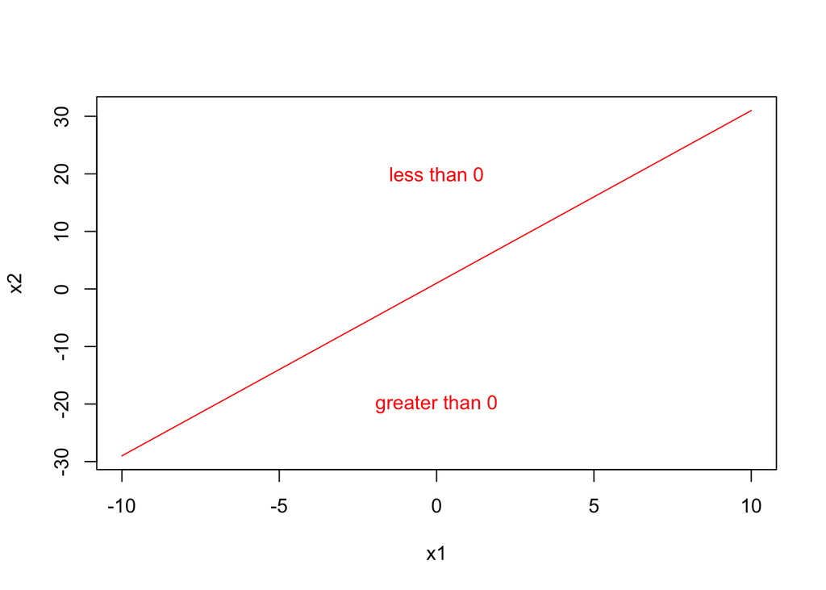

```r
x1 <- -10:10
x2 <- 1 + 3 * x1
plot(x1, x2, type = "l", col = "red")
text(c(0), c(-20), "greater than 0", col = "red")
text(c(0), c(20), "less than 0", col = "red")
```

### Qn 1.b

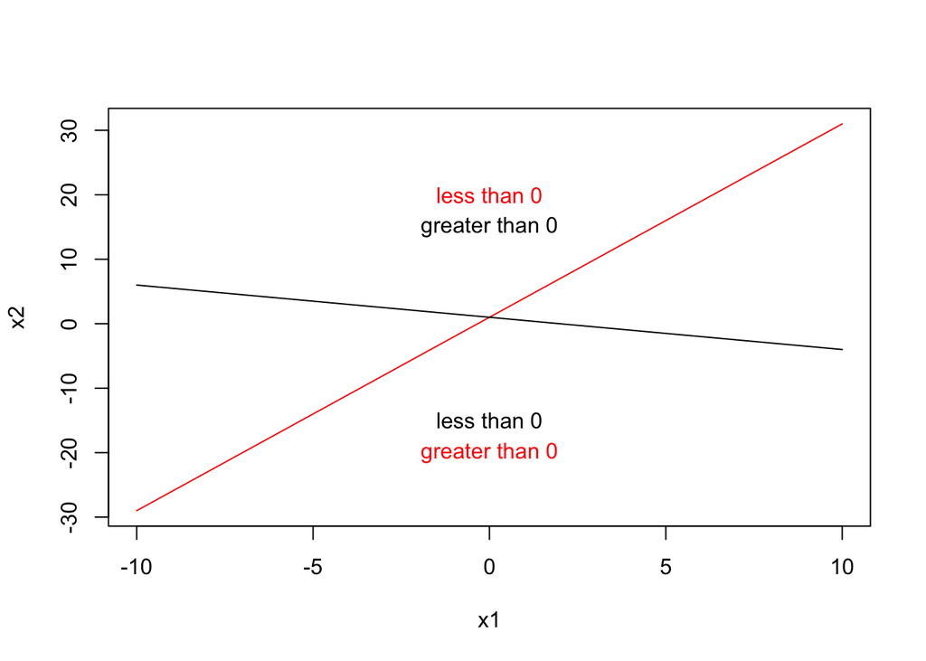

```r
x1 <- -10:10
x2 <- 1 + 3 * x1
plot(x1, x2, type = "l", col = "red")
text(c(0), c(-20), "greater than 0", col = "red")
text(c(0), c(20), "less than 0", col = "red")

lines(x1, 1 - x1/2)
text(c(0), c(-15), "less than 0")
text(c(0), c(15), "greater than 0")
```

### Qn 2.a

$(1+X_1)^2 + (2-X_2)^2 = 4$ is a circle with radius 2 and center (-1, 2).

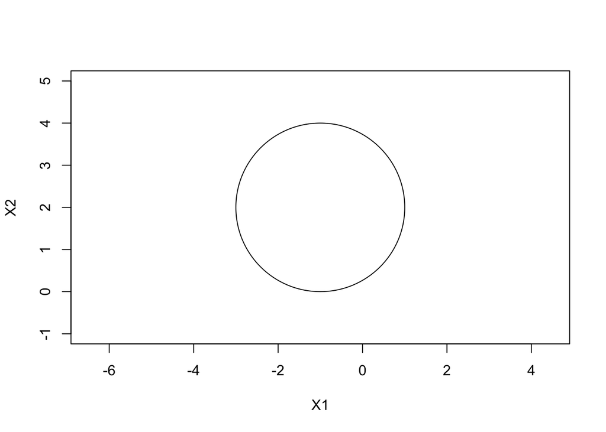

```r
radius <- 2
plot(NA, NA, type = "n", xlim = c(-4,2), ylim = c(-1,5), asp=1, xlab="X1", ylab="X2")
symbols(c(-1), c(2), circles=c(radius), add=TRUE, inches=FALSE)
```

### Qn 2.b

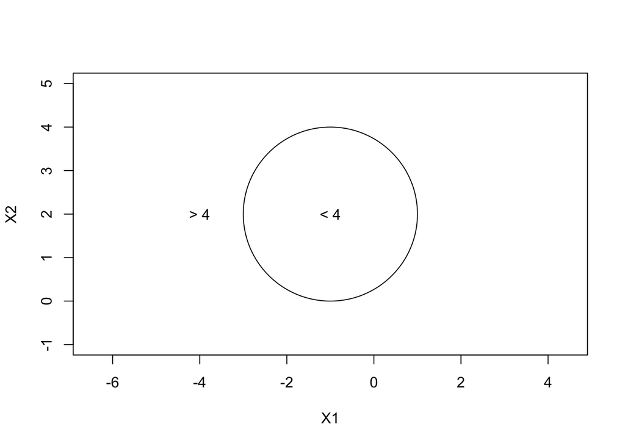

```r
radius <- 2
plot(NA, NA, type="n", xlim=c(-4,2), ylim=c(-1,5), asp=1, xlab="X1", ylab="X2")
symbols(c(-1), c(2), circles=c(radius), add=TRUE, inches=FALSE)
text(c(-1), c(2), "< 4")
text(c(-4), c(2), "> 4")
```

### Qn 2.c

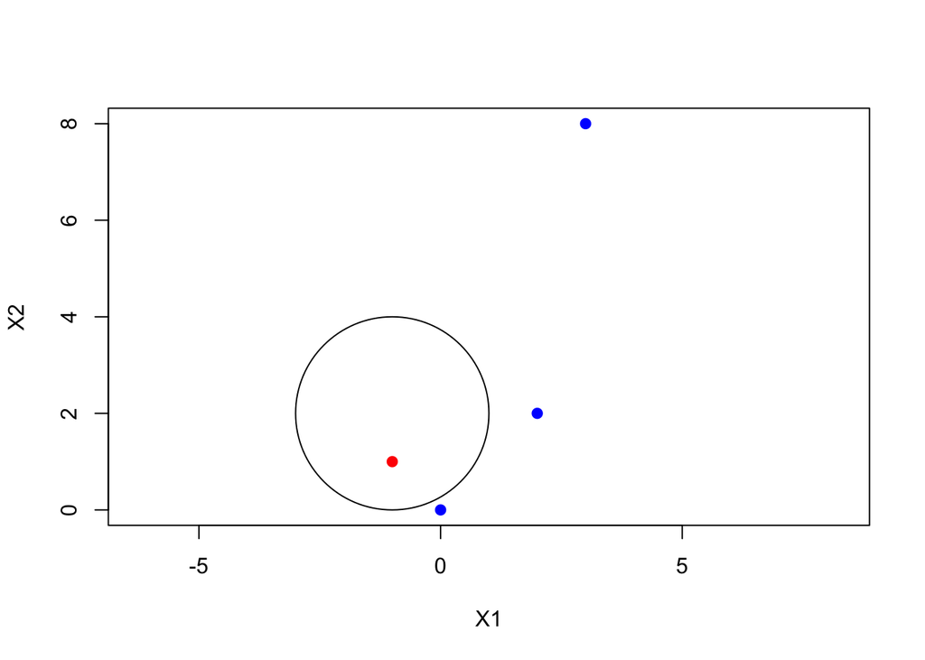

```r
radius <- 2
plot(c(0, -1, 2, 3), c(0, 1, 2, 8), col=c("blue", "red", "blue", "blue"),
     type="p", asp=1, xlab="X1", ylab="X2", pch = 19)
symbols(c(-1), c(2), circles=c(radius), add=TRUE, inches=FALSE)
```

### Qn 2.d

The decision boundary is a sum of quadratic terms when expanded.

$(1+X_1)^2 + (2-X_2)^2 > 4 \ 1 + 2 X_1 + X_1^2 + 4 - 4 X_2 + X_2^2 > 4 \ 5 + 2 X_1 - 4 X_2 + X_1^2 + X_2^2 > 4$

### Qn 3.a

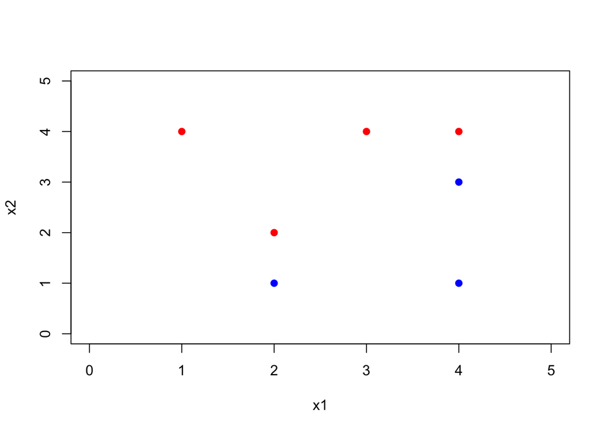

```r
x1 = c(3,2,4,1,2,4,4)
x2 = c(4,2,4,4,1,3,1)
colors = c("red", "red", "red", "red", "blue", "blue", "blue")
plot(x1,x2,col=colors,xlim=c(0,5),ylim=c(0,5), pch = 19)
```

### Qn 3.b

The maximal margin classifier has to be in between observations #2, #3 and #5, #6. We use these 4 points to first derive the two points on the decision boundary at x1 = 2 and x1 = 4. Then, we derive the gradient(b) and intercept(a).

$(2,2), (4,4) \ (2,1), (4,3) \ => (2,1.5), (4,3.5)$ $b = (3.5 - 1.5) / (4 - 2) = 1$ $a = X_2 - X_1 = 1.5 - 2 = -0.5$

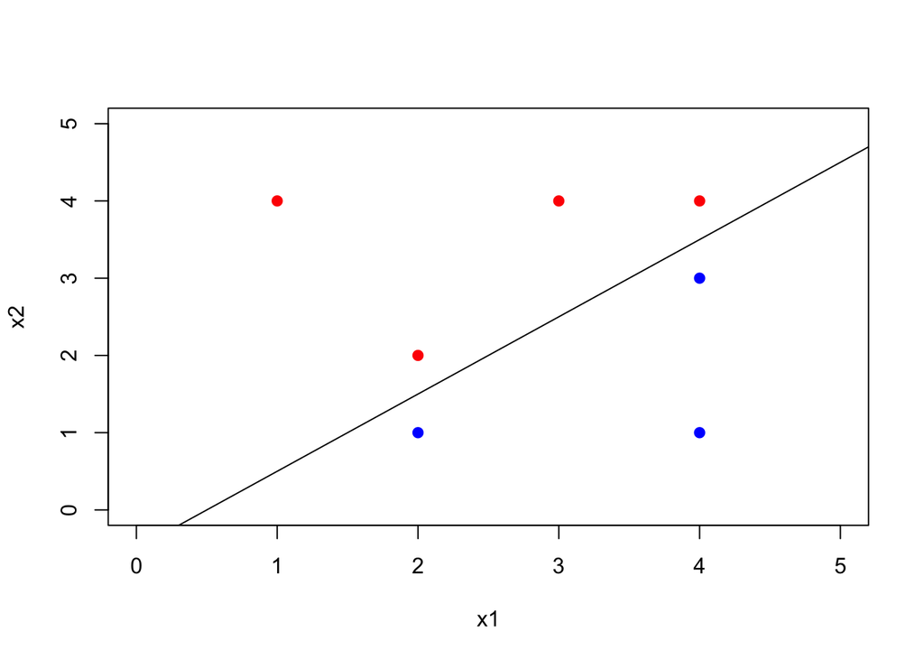

```r
plot(x1,x2,col=colors,xlim=c(0,5),ylim=c(0,5), pch = 19)
abline(-0.5, 1)
```

### Qn 3.c

Classify to red if $0.5 - X_1 + X_2 > 0$  
Classify to blue if $0.5 - X_1 + X_2 < 0$

### Qn 3.d

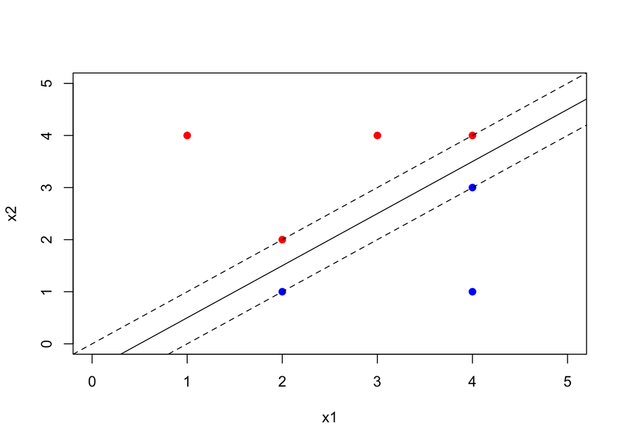

```r
plot(x1,x2,col=colors,xlim=c(0,5),ylim=c(0,5), pch = 19)
abline(-0.5, 1)
abline(-1, 1, lty=2)
abline(0, 1, lty=2)
```

### Qn 3.e

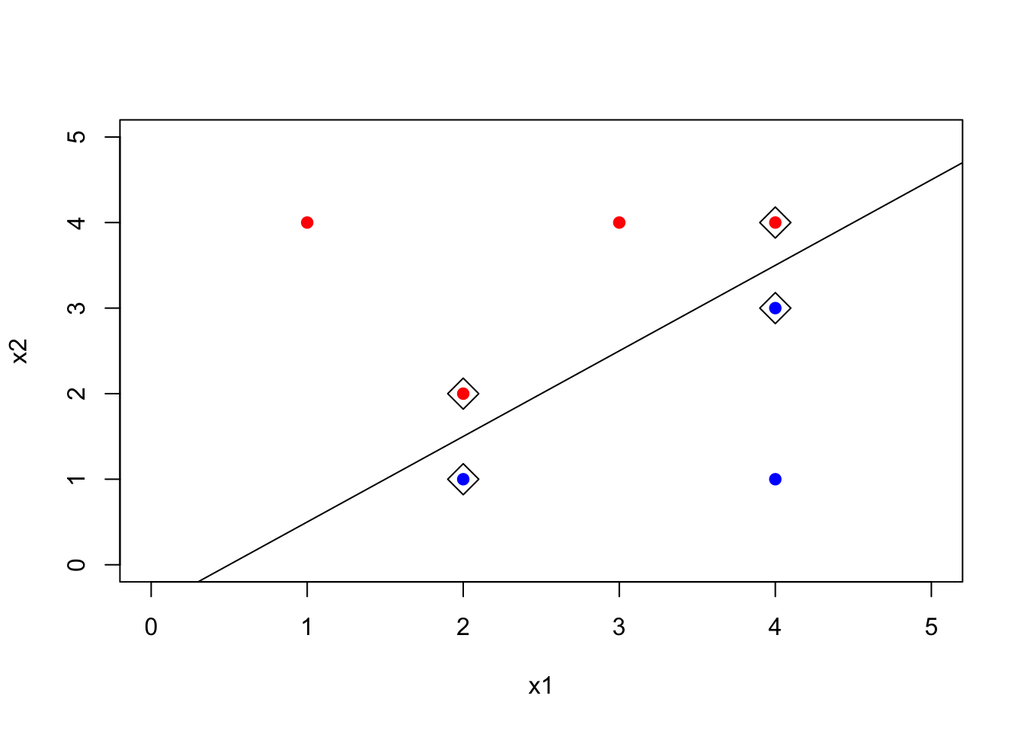

```r
plot(x1,x2,col=colors,xlim=c(0,5),ylim=c(0,5), pch = 19)
abline(-0.5, 1)
points(c(2, 2, 4, 4), c(1, 2, 3, 4), pch = 5, cex = 2, add = T)
```

### Qn 3.f

A slight movement of observation #7 (4,1) blue would not have an effect on the maximal margin hyperplane since its movement would be outside of the margin.

### Qn 3.g

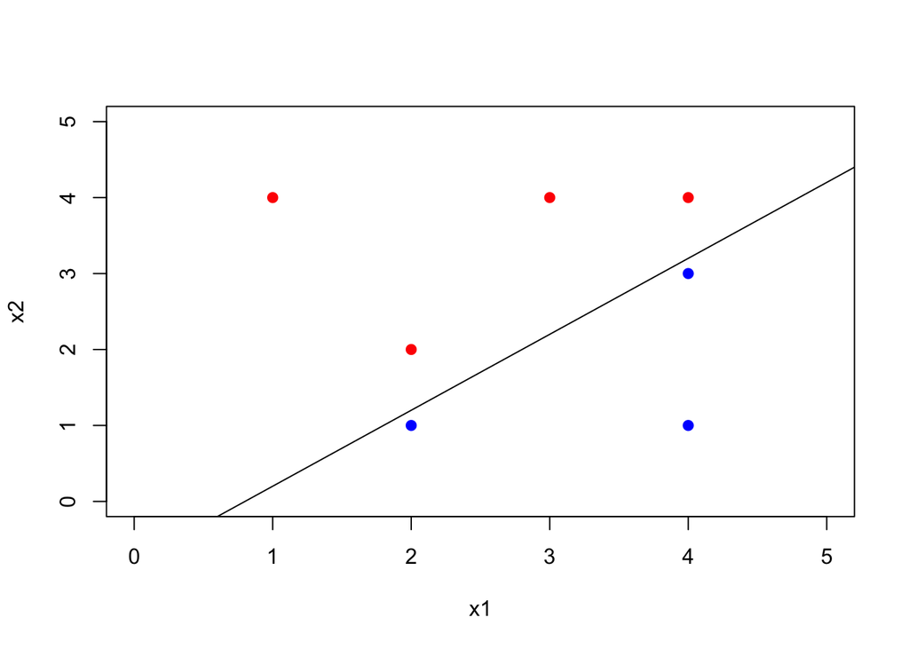

```r
plot(x1,x2,col=colors,xlim=c(0,5),ylim=c(0,5), pch = 19)
abline(-0.8, 1)
```

$-0.8 - X_1 + X_2 > 0$

### Qn 3.h

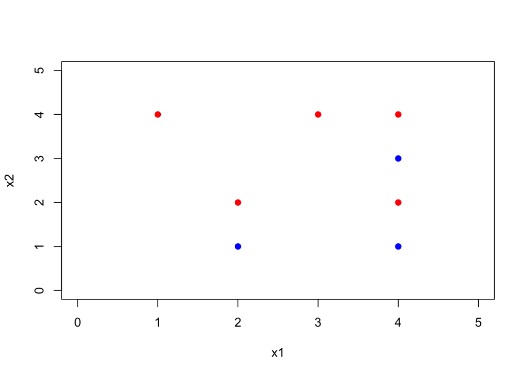

```r
plot(x1,x2,col=colors,xlim=c(0,5),ylim=c(0,5), pch = 19)
points(c(4), c(2), col=c("red"), pch = 19)
```